# 221710304026- CSE -221710304026-K.VIJAYALAKSHMI

# Problem Statement :

- This project aims through machine learning techniques at creating a model EmployeeAttrition Classification.
- Data includes Education,joblevel,jobinvolvement,Dailyrate,MonthlyIncome, Experience,No.ofCompaniesworked,Noofcompanieschanged ,Totalworkexperience Yearsatcompany,Yearsatcurrentrole, Yearssincelastpromotion,Yearswithcurrentmanager,Training timeslastyear,Performancerate,Attrition,By following above given data we finding the complete job profile of the person. -By this data and by satisfying the above given data we know the sustainable growth.Judges will look for evidence of how employees are engaged in strategic goals employees data and their experience in company and the level of the person in the company. -And by the graph and the plots we can prove it graphically.
- And we can the no of employees working in the company.

### Datasets and Inputs:

Given a dataset containing various attributes of EMPLOYEE ATTRITION. The dataset that I am working is downloaded from:

https://www.kaggle.com/HRAnalyticRepository/employee-attrition-data

### In this data:

- Education
- joblevel -jobinvolvement
- Dailyrate
- MonthlyIncome
- Experience
- No.ofCompaniesworked
- Noofcompanieschanged
- Totalworkexperience
- Yearsatcompany
- Yearsatcurrentrole
- Yearssincelastpromotion
- Yearswithcurrentmanager
- Training timeslastyear
- Performancerate
- Attrition

#### USES:

- This kind of prediction will help companies estimate Employee turnover(attrition) is a major cost to an organization, and predicting turnover is at the forefront of needs of Human Resources (HR) in many organizations.
- Until now the main stream approach has been to use logisticregression,KNN,etc to model employee attrition.

# LOAD required packages

```python
import pandas as pd
import numpy as np
import seaborn as sns
import matplotlib.pyplot as plt
%matplotlib inline
```

```python
# Reading the data from the dataset
data=pd.read_csv('/content/drive/My Drive/dp/EmployeeAttrition.csv')
data.head()
```

|  | Education | JobInvolvement | JobLevel | DailyRate(USD) | MonthlyIncome | NoofCompaniesWorked | TotalWorkingYears | YearsAtCompany | YearsInCurrentRole | YearsSinceLastPromotion | YearsWithCurrentManager | TrainingTimesLastYear | PerformanceRating | Attrition | Attrition_values |
| --- | --- | --- | --- | --- | --- | --- | --- | --- | --- | --- | --- | --- | --- | --- | --- |
| 0 | College | High | 2 | 1102 | 5993 | 8 | 8 | 6 | 4 | 0 | 5 | 0 | Excellent | Yes | 1 |
| 1 | Below College | Medium | 2 | 279 | 5130 | 1 | 10 | 10 | 7 | 1 | 7 | 3 | Outstanding | No | 0 |
| 2 | College | Medium | 1 | 1373 | 2090 | 6 | 7 | 0 | 0 | 0 | 0 | 3 | Excellent | Yes | 1 |
| 3 | Master | High | 1 | 1392 | 2909 | 1 | 8 | 8 | 7 | 3 | 0 | 3 | Excellent | No | 0 |
| 4 | Below College | High | 1 | 591 | 3468 | 9 | 6 | 2 | 2 | 2 | 2 | 3 | Excellent | No | 0 |

```python
# Reading the Dimensions of Your Data form dataset
data.shape
```

```
(1470, 15)
```

#### Descriptive statistics can give you great insight into the shape of each attribute.

- Often you can create more summaries than you have time to review. The describe() function on the Pandas DataFrame lists 8 statistical properties of each attribute:
- Count
- Mean
- Standard Devaition
- Minimum Value
- 25th Percentile
- 50th Percentile (Median)
- 75th Percentile
- Maximum Value

```python
data.describe().T
```

|  | count | mean | std | min | 25% | 50% | 75% | max |
| --- | --- | --- | --- | --- | --- | --- | --- | --- |
| JobLevel | 1470.0 | 2.063946 | 1.106940 | 1.0 | 1.0 | 2.0 | 3.0 | 5.0 |
| DailyRate(USD) | 1470.0 | 802.485714 | 403.509100 | 102.0 | 465.0 | 802.0 | 1157.0 | 1499.0 |
| MonthlyIncome | 1470.0 | 6502.931293 | 4707.956783 | 1009.0 | 2911.0 | 4919.0 | 8379.0 | 19999.0 |
| NoofCompaniesWorked | 1470.0 | 2.693197 | 2.498009 | 0.0 | 1.0 | 2.0 | 4.0 | 9.0 |
| TotalWorkingYears | 1470.0 | 11.279592 | 7.780782 | 0.0 | 6.0 | 10.0 | 15.0 | 40.0 |
| YearsAtCompany | 1470.0 | 7.008163 | 6.126525 | 0.0 | 3.0 | 5.0 | 9.0 | 40.0 |
| YearsInCurrentRole | 1470.0 | 4.229252 | 3.623137 | 0.0 | 2.0 | 3.0 | 7.0 | 18.0 |
| YearsSinceLastPromotion | 1470.0 | 2.187755 | 3.222430 | 0.0 | 0.0 | 1.0 | 3.0 | 15.0 |
| YearsWithCurrentManager | 1470.0 | 4.123129 | 3.568136 | 0.0 | 2.0 | 3.0 | 7.0 | 17.0 |
| TrainingTimesLastYear | 1470.0 | 2.799320 | 1.289271 | 0.0 | 2.0 | 3.0 | 3.0 | 6.0 |
| Attrition_values | 1470.0 | 0.159184 | 0.365972 | 0.0 | 0.0 | 0.0 | 0.0 | 1.0 |

```python
# Object to check null values form dataset
data.isnull().any()
```

```
Education                  False
JobInvolvement             False
JobLevel                   False
DailyRate(USD)             False
MonthlyIncome              False
NoofCompaniesWorked        False
TotalWorkingYears          False
YearsAtCompany             False
YearsInCurrentRole         False
YearsSinceLastPromotion    False
YearsWithCurrentManager    False
TrainingTimesLastYear      False
PerformanceRating          False
Attrition                  False
Attrition_values           False
dtype: bool
```

```python
#There are no null values in dataset
data.info()
```

```
<class 'pandas.core.frame.DataFrame'>
RangeIndex: 1470 entries, 0 to 1469
Data columns (total 15 columns):
 #   Column                   Non-Null Count  Dtype
---  ------                   --------------  -----
 0   Education                1470 non-null   object
 1   JobInvolvement           1470 non-null   object
 2   JobLevel                 1470 non-null   int64
 3   DailyRate(USD)           1470 non-null   int64
 4   MonthlyIncome            1470 non-null   int64
 5   NoofCompaniesWorked      1470 non-null   int64
 6   TotalWorkingYears        1470 non-null   int64
 7   YearsAtCompany           1470 non-null   int64
 8   YearsInCurrentRole       1470 non-null   int64
 9   YearsSinceLastPromotion  1470 non-null   int64
 10  YearsWithCurrentManager  1470 non-null   int64
 11  TrainingTimesLastYear    1470 non-null   int64
 12  PerformanceRating        1470 non-null   object
 13  Attrition                1470 non-null   object
 14  Attrition_values         1470 non-null   int64
dtypes: int64(11), object(4)
memory usage: 172.4+ KB
```

```python
data.select_dtypes(include=['int', 'float']).columns  #numerical
```

```
Index(['JobLevel', 'DailyRate(USD)', 'MonthlyIncome', 'NoofCompaniesWorked',
       'TotalWorkingYears', 'YearsAtCompany', 'YearsInCurrentRole',
       'YearsSinceLastPromotion', 'YearsWithCurrentManager',
       'TrainingTimesLastYear', 'Attrition_values'],
      dtype='object')
```

```python
data.Attrition  # target variable Attrition from dataset
```

```
0       Yes
1        No
2       Yes
3        No
4        No
       ...
1465     No
1466     No
1467     No
1468     No
1469     No
Name: Attrition, Length: 1470, dtype: object
```

```python
data.Attrition_values # target variable Attrition_values from dataset
```

```
0       1
1       0
2       1
3       0
4       0
       ..
1465    0
1466    0
1467    0
1468    0
1469    0
Name: Attrition_values, Length: 1470, dtype: int64
```

```python
data['JobInvolvement'].value_counts() # JobInvolvement variable size in different sections
```

```
High         868
Medium       375
Very High    144
Low           83
Name: JobInvolvement, dtype: int64
```

```python
data['Education'].value_counts()  # Education variable size  in different sections
```

```
Bachelor         572
Master           398
College          282
Below College    170
Doctor            48
Name: Education, dtype: int64
```

```python
data['Education'].unique()
```

```
array(['College', 'Below College', 'Master', 'Bachelor', 'Doctor'],
      dtype=object)
```

```python
data['Attrition'].value_counts() # target varible size
```

```
No     1233
Yes     237
Name: Attrition, dtype: int64
```

```python
data.groupby('Attrition').mean() #  count of certain (Attrition)categories, as well as the means sentiment score for these categories.
```

| Attrition | JobLevel | DailyRate(USD) | MonthlyIncome | NoofCompaniesWorked | TotalWorkingYears | YearsAtCompany | YearsInCurrentRole | YearsSinceLastPromotion | YearsWithCurrentManager | TrainingTimesLastYear | Attrition_values |
| --- | --- | --- | --- | --- | --- | --- | --- | --- | --- | --- | --- |
| No | 2.145985 | 812.504461 | 6832.739659 | 2.645580 | 11.862936 | 7.369019 | 4.484185 | 2.234388 | 4.367397 | 2.832928 | 0.000000 |
| Yes | 1.637131 | 750.362869 | 4787.092827 | 2.940928 | 8.244726 | 5.130802 | 2.902954 | 1.945148 | 2.852321 | 2.624473 | 0.987342 |

```python
data.groupby('JobInvolvement').mean()  # count of certain (JobInvolvement)categories, as well as the means sentiment score for these categories.
```

| JobInvolvement | JobLevel | DailyRate(USD) | MonthlyIncome | NoofCompaniesWorked | TotalWorkingYears | YearsAtCompany | YearsInCurrentRole | YearsSinceLastPromotion | YearsWithCurrentManager | TrainingTimesLastYear | Attrition_values |
| --- | --- | --- | --- | --- | --- | --- | --- | --- | --- | --- | --- |
| High | 2.072581 | 814.279954 | 6521.637097 | 2.750000 | 11.298387 | 6.906682 | 4.241935 | 2.203917 | 4.110599 | 2.824885 | 0.140553 |
| Low | 2.012048 | 726.951807 | 6418.108434 | 2.506024 | 11.192771 | 6.939759 | 4.253012 | 2.253012 | 3.987952 | 2.927711 | 0.337349 |
| Medium | 2.090667 | 787.968000 | 6609.648000 | 2.637333 | 11.346667 | 7.330667 | 4.162667 | 2.256000 | 4.053333 | 2.754667 | 0.189333 |
| Very High | 1.972222 | 812.736111 | 6161.159722 | 2.604167 | 11.041667 | 6.819444 | 4.312500 | 1.875000 | 4.458333 | 2.687500 | 0.090278 |

```python
data.groupby('MonthlyIncome').mean() # count of certain (MonthlyIncome)categories, as well as the means sentiment score for these categories.
```

| MonthlyIncome | JobLevel | DailyRate(USD) | NoofCompaniesWorked | TotalWorkingYears | YearsAtCompany | YearsInCurrentRole | YearsSinceLastPromotion | YearsWithCurrentManager | TrainingTimesLastYear | Attrition_values |
| --- | --- | --- | --- | --- | --- | --- | --- | --- | --- | --- |
| 1009 | 1.0 | 1362.0 | 1.0 | 1.0 | 1.0 | 0.0 | 1.0 | 1.0 | 5.0 | 1.0 |
| 1051 | 1.0 | 287.0 | 1.0 | 0.0 | 0.0 | 0.0 | 0.0 | 0.0 | 2.0 | 0.0 |
| 1052 | 1.0 | 1144.0 | 1.0 | 1.0 | 1.0 | 0.0 | 0.0 | 0.0 | 5.0 | 0.0 |
| 1081 | 1.0 | 945.0 | 1.0 | 1.0 | 1.0 | 0.0 | 0.0 | 0.0 | 3.0 | 1.0 |
| 1091 | 1.0 | 746.0 | 1.0 | 1.0 | 1.0 | 0.0 | 0.0 | 0.0 | 3.0 | 1.0 |
| ... | ... | ... | ... | ... | ... | ... | ... | ... | ... | ... |
| 19859 | 5.0 | 725.0 | 5.0 | 24.0 | 5.0 | 2.0 | 1.0 | 4.0 | 2.0 | 1.0 |
| 19926 | 5.0 | 1452.0 | 3.0 | 21.0 | 5.0 | 4.0 | 4.0 | 4.0 | 5.0 | 0.0 |
| 19943 | 5.0 | 718.0 | 4.0 | 28.0 | 5.0 | 2.0 | 4.0 | 2.0 | 2.0 | 0.0 |
| 19973 | 5.0 | 247.0 | 1.0 | 21.0 | 21.0 | 16.0 | 5.0 | 10.0 | 3.0 | 0.0 |
| 19999 | 5.0 | 699.0 | 0.0 | 34.0 | 33.0 | 18.0 | 11.0 | 9.0 | 5.0 | 0.0 |

1349 rows × 10 columns

```python
data.corr() # Correlation refers to the relationship between two variables and how they may or may not change together.
```

|  | JobLevel | DailyRate(USD) | MonthlyIncome | NoofCompaniesWorked | TotalWorkingYears | YearsAtCompany | YearsInCurrentRole | YearsSinceLastPromotion | YearsWithCurrentManager | TrainingTimesLastYear | Attrition_values |
| --- | --- | --- | --- | --- | --- | --- | --- | --- | --- | --- | --- |
| JobLevel | 1.000000 | 0.002966 | 0.950300 | 0.142501 | 0.782208 | 0.534739 | 0.389447 | 0.353885 | 0.375281 | -0.018191 | -0.166296 |
| DailyRate(USD) | 0.002966 | 1.000000 | 0.007707 | 0.038153 | 0.014515 | -0.034055 | 0.009932 | -0.033229 | -0.026363 | 0.002453 | -0.058966 |
| MonthlyIncome | 0.950300 | 0.007707 | 1.000000 | 0.149515 | 0.772893 | 0.514285 | 0.363818 | 0.344978 | 0.344079 | -0.021736 | -0.157493 |
| NoofCompaniesWorked | 0.142501 | 0.038153 | 0.149515 | 1.000000 | 0.237639 | -0.118421 | -0.090754 | -0.036814 | -0.110319 | -0.066054 | 0.045267 |
| TotalWorkingYears | 0.782208 | 0.014515 | 0.772893 | 0.237639 | 1.000000 | 0.628133 | 0.460365 | 0.404858 | 0.459188 | -0.035662 | -0.172225 |
| YearsAtCompany | 0.534739 | -0.034055 | 0.514285 | -0.118421 | 0.628133 | 1.000000 | 0.758754 | 0.618409 | 0.769212 | 0.003569 | -0.132043 |
| YearsInCurrentRole | 0.389447 | 0.009932 | 0.363818 | -0.090754 | 0.460365 | 0.758754 | 1.000000 | 0.548056 | 0.714365 | -0.005738 | -0.156401 |
| YearsSinceLastPromotion | 0.353885 | -0.033229 | 0.344978 | -0.036814 | 0.404858 | 0.618409 | 0.548056 | 1.000000 | 0.510224 | -0.002067 | -0.034019 |
| YearsWithCurrentManager | 0.375281 | -0.026363 | 0.344079 | -0.110319 | 0.459188 | 0.769212 | 0.714365 | 0.510224 | 1.000000 | -0.004096 | -0.155250 |
| TrainingTimesLastYear | -0.018191 | 0.002453 | -0.021736 | -0.066054 | -0.035662 | 0.003569 | -0.005738 | -0.002067 | -0.004096 | 1.000000 | -0.053440 |
| Attrition_values | -0.166296 | -0.058966 | -0.157493 | 0.045267 | -0.172225 | -0.132043 | -0.156401 | -0.034019 | -0.155250 | -0.053440 | 1.000000 |

# Data Visualization

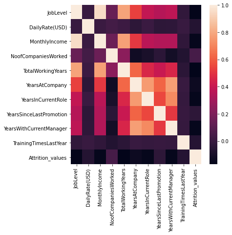

```python
fig = plt.figure(figsize=(6,6)) # heatmap graphplot for correlation of varibales.
sns.heatmap(data.corr())
```

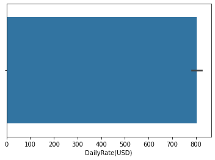

```python
#detection of outlier using boxplot
sns.barplot(data['DailyRate(USD)'])
```

### Visualize the number of employess that stayed and left company

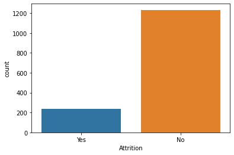

```python
sns.countplot(data['Attrition'])
```

The above bar chart shows the number of employess that stayed 1300(aprox) and left company 250(aprox)

### Shows the number of employees that left and corresponding companiesworked.

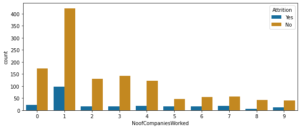

```python
plt.subplots(figsize=(10,4))
sns.countplot(x='NoofCompaniesWorked', hue='Attrition', data = data, palette = 'colorblind')
```

The above bar chart shows the number of employess that worked on different compaines(NoofCompaniesWorked) with employees leaving(highest 1 company and 8 compaines lowest) and not leaving(highest 1 company and 8 compaines lowest)

### Shows the MonthlyIncome with the respective YearsAtCompany

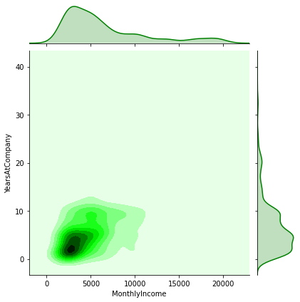

```python
sns.jointplot(x = 'MonthlyIncome', y = 'YearsAtCompany' , data = data , color = 'green', kind = 'kde' )
```

Joint Plot can also display data using Kernel Density Estimate (KDE) and Hexagons.

### Shows the number of employees that left vs DailyRate(USD)

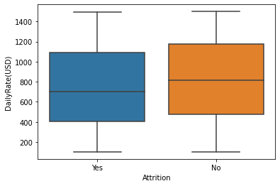

```python
sns.boxplot(x= 'Attrition', y= 'DailyRate(USD)', data = data)
```

By looking at the above box plot we can say that attrition occur is compared to dailyrate there is no distinction between them.

### Shows the number of employees that left with corresponding JobInvolvement

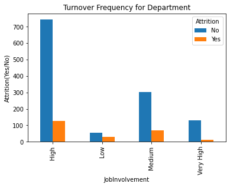

```python
%matplotlib inline
import matplotlib.pyplot as plt
pd.crosstab(data.JobInvolvement,data.Attrition).plot(kind='bar')
plt.title('Turnover Frequency for Department')
plt.xlabel('JobInvolvement')
plt.ylabel('Attrition(Yes/No)')
plt.savefig('attrition_bar_chart')
```

### shows the profile leaving employees

```
0    1236
1     234
Name: Attrition_values, dtype: int64
```

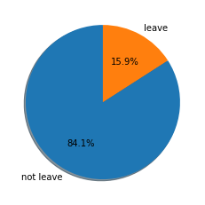

```python
# Getting the cocunt of people who leave and not leave
leftcounts=data['Attrition_values'].value_counts()
print(leftcounts)

# Using matplotlib pie chart and label the pie chart
plt.pie(leftcounts,labels=['not leave','leave'],autopct='%1.1f%%',shadow=True,startangle=90);
```

The above pie chart shows the % of employees leaving(15.9%) and not leaving(84.1%)

```python
# Getting data of employee who leave and do not leave
leftdata=data[data['Attrition_values']==1]
notleftdata=data[data['Attrition_values']==0]

# Getting the shapes and number of these people
print("shape of leftdata",leftdata.shape)
print("shape of notleftdata",notleftdata.shape)
```

```
shape of leftdata (234, 15)
shape of notleftdata (1236, 15)
```

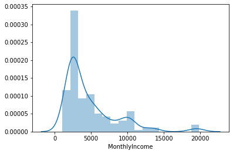

```python
# Getting the distribution of MonthlyIncome
sns.distplot(leftdata['MonthlyIncome'])
```

The above plot describes the MonthlyIncome of employee

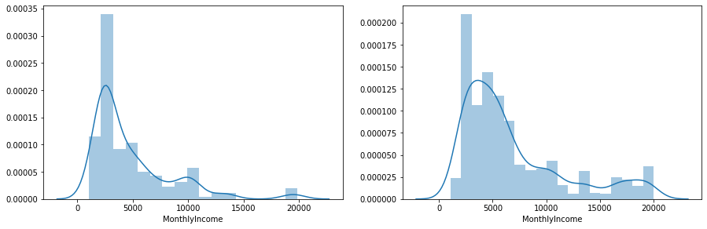

```python
# Create a figure instance and the two subplots
fig=plt.figure(figsize=(15,10))
ax1=fig.add_subplot(221)
ax2=fig.add_subplot(222)

sns.distplot(leftdata['MonthlyIncome'],ax=ax1);
sns.distplot(notleftdata['MonthlyIncome'],ax=ax2);
```

The above plot tells about the MonthlyIncome of leave and not leave employees.There is a somewhat average veriation .

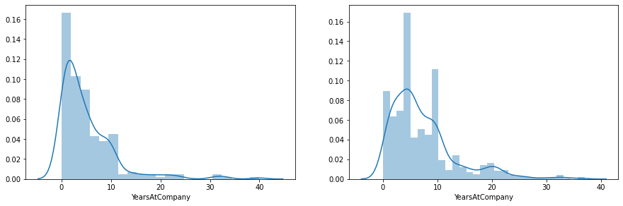

```python
#Create a figure instance and the two subplots
fig=plt.figure(figsize=(15,10))
ax1=fig.add_subplot(221)
ax2=fig.add_subplot(222)

sns.distplot(leftdata['YearsAtCompany'],kde=True,ax=ax1)

sns.distplot(notleftdata['YearsAtCompany'],kde=True,ax=ax2)
```

The above plot tells about the YearsAtCompany of leave and not leave employees.There is a average/little veriation .

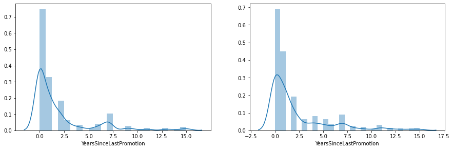

```python
#Create a figure instance and the two subplots
fig=plt.figure(figsize=(15,10))
ax1=fig.add_subplot(221)
ax2=fig.add_subplot(222)

sns.distplot(leftdata['YearsSinceLastPromotion'],kde=True,ax=ax1)

sns.distplot(notleftdata['YearsSinceLastPromotion'],kde=True,ax=ax2)
```

The above plot tells about the YearsSinceLastPromotion of leave and not leave employees.There is a little veriation .

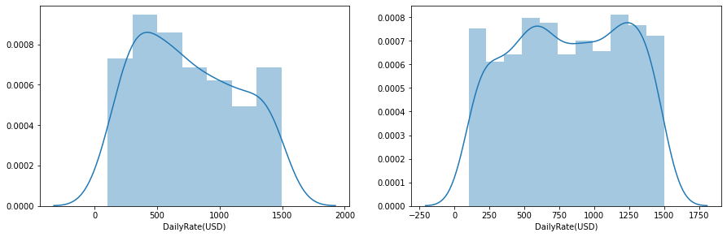

```python
#Create a figure instance and the two subplots
fig=plt.figure(figsize=(15,10))
ax1=fig.add_subplot(221)
ax2=fig.add_subplot(222)

sns.distplot(leftdata['DailyRate(USD)'],kde=True,ax=ax1)

sns.distplot(notleftdata['DailyRate(USD)'],kde=True,ax=ax2)
```

The above plot tells about the DailyRate(USD) of leave and not leave employees.There is a least average veriation .

[output not shown]

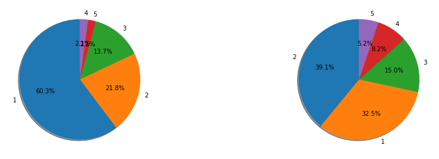

```python
#Create a figure with  two subplots
fig=plt.figure(figsize=(15,10))
ax1=fig.add_subplot(221)
ax2=fig.add_subplot(222)

leftworkaccidentcounts=leftdata['JobLevel'].value_counts()
notleftworkaccidentcounts=notleftdata['JobLevel'].value_counts()

# Plot each pie chart in a separate subplot
ax1.pie(leftworkaccidentcounts,labels=leftworkaccidentcounts.index,autopct='%1.1f%%',shadow=True,startangle=90)
ax2.pie(notleftworkaccidentcounts,labels=notleftworkaccidentcounts.index,autopct='%1.1f%%',shadow=True,startangle=90)
```

The above pie chart shows the JobLevel% of employees leaving(max 60.3% and min 2.2%) and not leaving(max 39.1% and min 5.2%)

[output not shown]

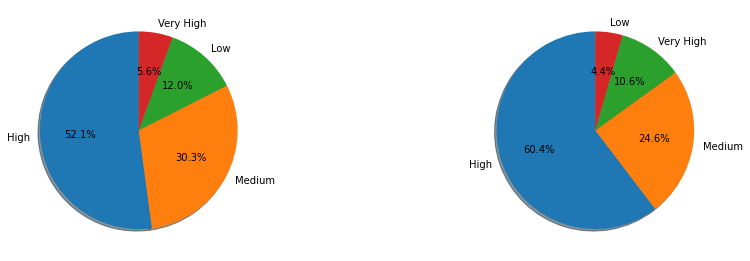

```python
#Create a figure with  two subplots
fig=plt.figure(figsize=(15,10))
ax1=fig.add_subplot(221)
ax2=fig.add_subplot(222)

leftdepartmentcounts=leftdata['JobInvolvement'].value_counts()
notleftdepartmentcounts=notleftdata['JobInvolvement'].value_counts()

# Plot each pie chart in a separate subplot
ax1.pie(leftdepartmentcounts,labels=leftdepartmentcounts.index,autopct='%1.1f%%',shadow=True,startangle=90)
ax2.pie(notleftdepartmentcounts,labels=notleftdepartmentcounts.index,autopct='%1.1f%%',shadow=True,startangle=90)
```

The above pie chart shows the JobInvolvement% of employees leaving(max 52.1% and min 5.6%) and not leaving(max 60.4% and min 4.4%)

[output not shown]

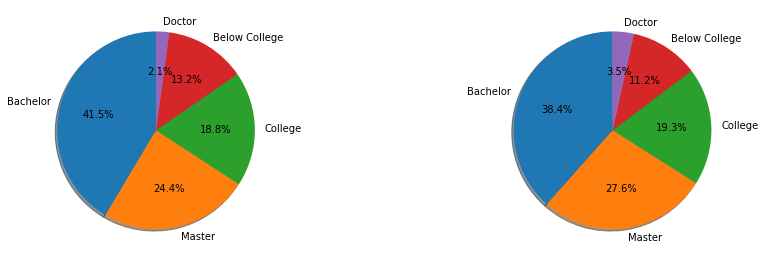

```python
#Create a figure with  two subplots
fig=plt.figure(figsize=(15,10))
ax1=fig.add_subplot(221)
ax2=fig.add_subplot(222)

leftdepartmentcounts=leftdata['Education'].value_counts()
notleftdepartmentcounts=notleftdata['Education'].value_counts()

# Plot each pie chart in a separate subplot
ax1.pie(leftdepartmentcounts,labels=leftdepartmentcounts.index,autopct='%1.1f%%',shadow=True,startangle=90)
ax2.pie(notleftdepartmentcounts,labels=notleftdepartmentcounts.index,autopct='%1.1f%%',shadow=True,startangle=90)
```

The above pie chart shows the Education% of employees leaving(max 41.5% and min 2.1%) and not leaving(max 38.4% and min 3.5%)

#### check Better Heatmaps and Correlation Matrix Plots.

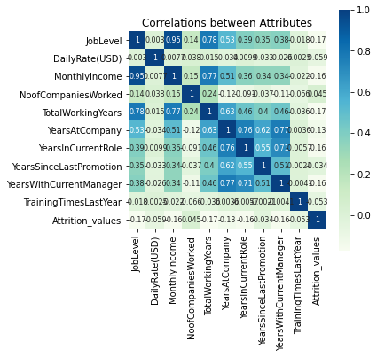

```python
fig = plt.subplots (figsize = (5,5))
sns.heatmap(data.corr (), square = True, cbar = True, annot = True, cmap="GnBu", annot_kws = {'size': 8})
plt.title('Correlations between Attributes')
plt.show ()
```

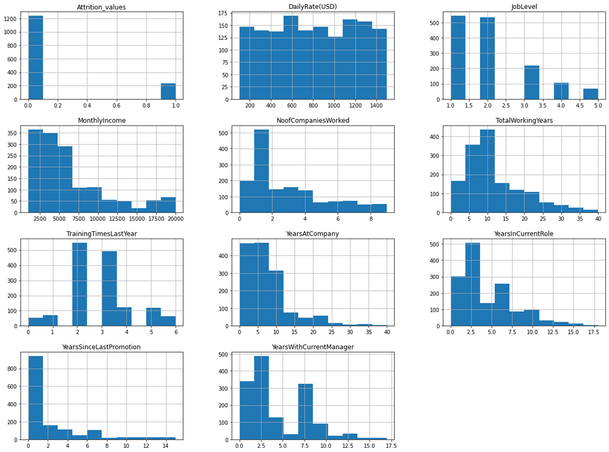

```python
num_bins = 10
data.hist(bins=num_bins, figsize=(20,15))
plt.savefig("attrition_histogram_plots")
plt.show()
```

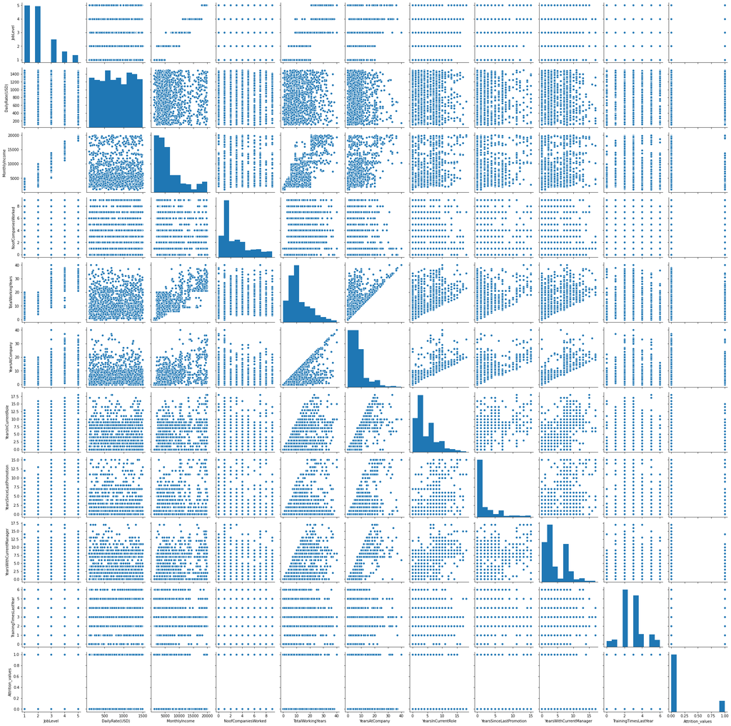

```python
# Plot pairwise relationships in a dataset.
# Seaborn - Visualizing Pairwise Relationship
# To plot multiple pairwise bivariate distributions in a dataset, you can use the pairplot() function.
sns.pairplot(data)
```

The above plot chart shows the multiple pairwise bivariate distributions in a dataset of attributes

# Train and Test the model

- After the completion of preprocessing steps, the data splits into training and testing datasets to train the classifier and checks its accuracy.We will be using one or more classification algorithms.We use algorithms like Logistics regression,Random forest,K-nearest neighbors(KNN).

```python
X=data.drop(['Attrition_values', 'JobInvolvement', 'Education', 'PerformanceRating', 'Attrition'], axis=1)
y=data.drop(['JobInvolvement', 'Education', 'PerformanceRating', 'Attrition'], axis=1).iloc[:,-1]
```

```python
X.head() # The head() function is used to get the first n rows
```

|  | JobLevel | DailyRate(USD) | MonthlyIncome | NoofCompaniesWorked | TotalWorkingYears | YearsAtCompany | YearsInCurrentRole | YearsSinceLastPromotion | YearsWithCurrentManager | TrainingTimesLastYear |
| --- | --- | --- | --- | --- | --- | --- | --- | --- | --- | --- |
| 0 | 2 | 1102 | 5993 | 8 | 8 | 6 | 4 | 0 | 5 | 0 |
| 1 | 2 | 279 | 5130 | 1 | 10 | 10 | 7 | 1 | 7 | 3 |
| 2 | 1 | 1373 | 2090 | 6 | 7 | 0 | 0 | 0 | 0 | 3 |
| 3 | 1 | 1392 | 2909 | 1 | 8 | 8 | 7 | 3 | 0 | 3 |
| 4 | 1 | 591 | 3468 | 9 | 6 | 2 | 2 | 2 | 2 | 3 |

```python
y.head() # The head() function is used to get the first n rows
```

```
0    1
1    0
2    1
3    0
4    0
Name: Attrition_values, dtype: int64
```

#### Preparing Training and Testing Data

#### Storing 80% of the data(rows) into training and remaining 20% of the data(rows) into testing

```python
from sklearn.model_selection import train_test_split
from sklearn import metrics
from sklearn.metrics import classification_report, confusion_matrix, accuracy_score
X_train, X_test, y_train, y_test = train_test_split(X, y, test_size = 0.2, random_state = 99)
```

```python
print(X_train.shape) #i/p train --> o/p train
print(X_test.shape)  #i/p test --> o/p test
print(y_train.shape) #o/p train
print(y_test.shape)  #o/p test
```

```
(1176, 10)
(294, 10)
(1176,)
(294,)
```

```python
X_train # X_train are the features you are using as input for the training model
```

|  | JobLevel | DailyRate(USD) | MonthlyIncome | NoofCompaniesWorked | TotalWorkingYears | YearsAtCompany | YearsInCurrentRole | YearsSinceLastPromotion | YearsWithCurrentManager | TrainingTimesLastYear |
| --- | --- | --- | --- | --- | --- | --- | --- | --- | --- | --- |
| 668 | 1 | 995 | 2377 | 5 | 6 | 2 | 2 | 2 | 2 | 2 |
| 1380 | 2 | 682 | 5561 | 0 | 6 | 5 | 3 | 0 | 4 | 2 |
| 58 | 2 | 655 | 5915 | 3 | 10 | 7 | 7 | 1 | 7 | 3 |
| 1095 | 2 | 589 | 5207 | 1 | 15 | 15 | 14 | 5 | 7 | 3 |
| 88 | 2 | 288 | 4152 | 1 | 11 | 11 | 10 | 10 | 8 | 3 |
| ... | ... | ... | ... | ... | ... | ... | ... | ... | ... | ... |
| 1092 | 1 | 950 | 2132 | 4 | 8 | 5 | 4 | 0 | 3 | 3 |
| 1192 | 1 | 464 | 2587 | 4 | 17 | 2 | 2 | 2 | 2 | 2 |
| 1209 | 3 | 370 | 10883 | 3 | 19 | 1 | 0 | 0 | 0 | 2 |
| 1059 | 1 | 660 | 2404 | 1 | 1 | 1 | 0 | 0 | 0 | 3 |
| 641 | 2 | 379 | 6524 | 1 | 10 | 10 | 8 | 5 | 3 | 3 |

1176 rows × 10 columns

```python
X_test # X_test are the features you are using as input for the testing model
```

|  | JobLevel | DailyRate(USD) | MonthlyIncome | NoofCompaniesWorked | TotalWorkingYears | YearsAtCompany | YearsInCurrentRole | YearsSinceLastPromotion | YearsWithCurrentManager | TrainingTimesLastYear |
| --- | --- | --- | --- | --- | --- | --- | --- | --- | --- | --- |
| 1328 | 2 | 728 | 3540 | 1 | 9 | 9 | 8 | 5 | 8 | 5 |
| 725 | 1 | 622 | 3743 | 1 | 5 | 4 | 2 | 0 | 2 | 2 |
| 74 | 1 | 132 | 3038 | 3 | 5 | 1 | 0 | 0 | 0 | 3 |
| 1132 | 2 | 118 | 4639 | 1 | 5 | 5 | 4 | 1 | 2 | 2 |
| 1042 | 1 | 981 | 3162 | 3 | 7 | 5 | 2 | 0 | 3 | 5 |
| ... | ... | ... | ... | ... | ... | ... | ... | ... | ... | ... |
| 961 | 2 | 482 | 4249 | 1 | 9 | 9 | 6 | 1 | 1 | 3 |
| 865 | 2 | 1329 | 4115 | 8 | 8 | 4 | 3 | 0 | 3 | 3 |
| 65 | 4 | 836 | 14756 | 2 | 21 | 5 | 0 | 0 | 2 | 2 |
| 1031 | 3 | 377 | 10096 | 4 | 28 | 7 | 7 | 4 | 3 | 1 |
| 342 | 3 | 1232 | 7143 | 1 | 11 | 11 | 9 | 4 | 10 | 2 |

294 rows × 10 columns

```python
y_train # Y_train are the expected outcomes/labels for training model
```

```
668     0
1380    0
58      0
1095    0
88      0
       ..
1092    0
1192    0
1209    0
1059    0
641     0
Name: Attrition_values, Length: 1176, dtype: int64
```

```python
y_test # Y_train are the expected outcomes/labels for testing model
```

```
1328    0
725     1
74      0
1132    0
1042    0
       ..
961     0
865     0
65      0
1031    1
342     0
Name: Attrition_values, Length: 294, dtype: int64
```

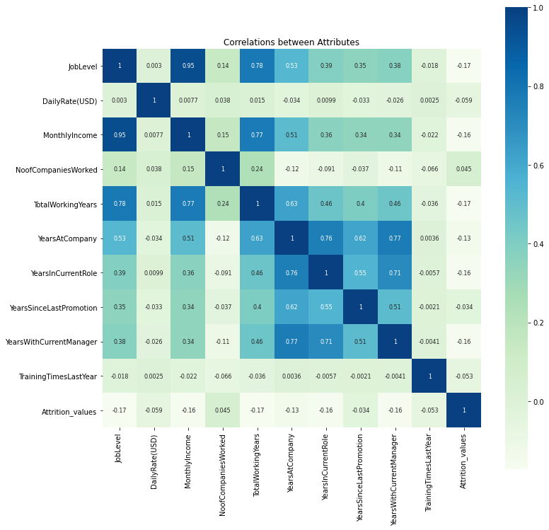

```python
# check Better Heatmaps and Correlation Matrix Plots.
fig = plt.subplots (figsize = (12,12))
sns.heatmap(data.corr (), square = True , cbar = True , annot = True, cmap="GnBu", annot_kws = {'size': 8})
plt.title('Correlations between Attributes')
plt.show()
```

#### Before Splitting if you apply standardization--> you are considering whole

#### you are including test data also into training data

```python
## Scaling Data
from sklearn.preprocessing import StandardScaler
scaler = StandardScaler()
```

```python
# Scaling for training data
scaled_X_train = pd.DataFrame(scaler.fit_transform(X_train))
scaled_X_train
```

|  | 0 | 1 | 2 | 3 | 4 | 5 | 6 | 7 | 8 | 9 |
| --- | --- | --- | --- | --- | --- | --- | --- | --- | --- | --- |
| 0 | -0.976541 | 0.458008 | -0.896293 | 0.932322 | -0.691202 | -0.813353 | -0.620601 | -0.072790 | -0.589095 | -0.628958 |
| 1 | -0.082139 | -0.322843 | -0.228803 | -1.085364 | -0.691202 | -0.323425 | -0.343942 | -0.686416 | -0.026549 | -0.628958 |
| 2 | -0.082139 | -0.390201 | -0.154591 | 0.125248 | -0.177875 | 0.003194 | 0.762695 | -0.379603 | 0.817271 | 0.156238 |
| 3 | -0.082139 | -0.554853 | -0.303015 | -0.681827 | 0.463784 | 1.309669 | 2.699310 | 0.847649 | 0.817271 | 0.156238 |
| 4 | -0.082139 | -1.305767 | -0.524184 | -0.681827 | -0.049543 | 0.656432 | 1.592673 | 2.381713 | 1.098544 | 0.156238 |
| ... | ... | ... | ... | ... | ... | ... | ... | ... | ... | ... |
| 1171 | -0.976541 | 0.345745 | -0.947654 | 0.528785 | -0.434538 | -0.323425 | -0.067283 | -0.686416 | -0.307822 | 0.156238 |
| 1172 | -0.976541 | -0.866694 | -0.852269 | 0.528785 | 0.720447 | -0.813353 | -0.620601 | -0.072790 | -0.589095 | -0.628958 |
| 1173 | 0.812263 | -1.101199 | 0.886894 | 0.125248 | 0.977111 | -0.976662 | -1.173920 | -0.686416 | -1.151641 | -0.628958 |
| 1174 | -0.976541 | -0.377727 | -0.890633 | -0.681827 | -1.332860 | -0.976662 | -1.173920 | -0.686416 | -1.151641 | 0.156238 |
| 1175 | -0.082139 | -1.078747 | -0.026921 | -0.681827 | -0.177875 | 0.493122 | 1.039354 | 0.847649 | -0.307822 | 0.156238 |

1176 rows × 10 columns

```python
#Scaling for test data
#Testing the data based on training data
scaled_X_test = pd.DataFrame(scaler.fit_transform(X_test))
scaled_X_test
```

|  | 0 | 1 | 2 | 3 | 4 | 5 | 6 | 7 | 8 | 9 |
| --- | --- | --- | --- | --- | --- | --- | --- | --- | --- | --- |
| 0 | 0.045268 | -0.094287 | -0.538526 | -0.663877 | -0.240543 | 0.306966 | 1.048186 | 0.984788 | 1.041821 | 1.637422 |
| 1 | -0.905357 | -0.351947 | -0.492301 | -0.663877 | -0.759585 | -0.509019 | -0.595369 | -0.650961 | -0.619818 | -0.587857 |
| 2 | -0.905357 | -1.543018 | -0.652835 | 0.113732 | -0.759585 | -0.998610 | -1.143221 | -0.650961 | -1.173697 | 0.153903 |
| 3 | 0.045268 | -1.577049 | -0.288275 | -0.663877 | -0.759585 | -0.345822 | -0.047518 | -0.323812 | -0.619818 | -0.587857 |
| 4 | -0.905357 | 0.520695 | -0.624599 | 0.113732 | -0.500064 | -0.345822 | -0.595369 | -0.650961 | -0.342878 | 1.637422 |
| ... | ... | ... | ... | ... | ... | ... | ... | ... | ... | ... |
| 289 | 0.045268 | -0.692253 | -0.377081 | -0.663877 | -0.240543 | 0.306966 | 0.500334 | -0.323812 | -0.896757 | 0.153903 |
| 290 | 0.045268 | 1.366598 | -0.407594 | 2.057755 | -0.370303 | -0.509019 | -0.321444 | -0.650961 | -0.342878 | 0.153903 |
| 291 | 1.946519 | 0.168235 | 2.015441 | -0.275073 | 1.316584 | -0.345822 | -1.143221 | -0.650961 | -0.619818 | -0.587857 |
| 292 | 0.995893 | -0.947483 | 0.954324 | 0.502536 | 2.224908 | -0.019428 | 0.774260 | 0.657638 | -0.342878 | -1.329617 |
| 293 | 0.995893 | 1.130815 | 0.281904 | -0.663877 | 0.018979 | 0.633360 | 1.322111 | 0.657638 | 1.595701 | -0.587857 |

294 rows × 10 columns

# Training and Testing the model with Algorithms

- K-nearest neighbors(KNN)
- Logistics regression
- Random forest

# K-nearest neighbors(KNN) Algorithm Model

```python
# Model Building:
from sklearn.neighbors import KNeighborsClassifier
knn = KNeighborsClassifier(n_neighbors=40, metric='euclidean')

# Apply the knn object on the dataset(Training Phase)
# Syntax: objectName.fit(Input, Output)
knn.fit(scaled_X_train, y_train)
```

```
KNeighborsClassifier(algorithm='auto', leaf_size=30, metric='euclidean',
                     metric_params=None, n_jobs=None, n_neighbors=40, p=2,
                     weights='uniform')
```

```python
# Predictions on the data
#predict function--> gives the predicted values for training model
# Syntax:objectname.predict(Input)
y_train_pred_knn = knn.predict(scaled_X_train)
y_train_pred_knn
```

```
array([0, 0, 0, ..., 0, 0, 0])
```

```python
# Checks the confusion_matrix for training model
confusion_matrix = metrics.confusion_matrix(y_train, y_train_pred_knn)
confusion_matrix
```

```
array([[993,   0],
       [183,   0]])
```

```python
# Checks the accuracy, classification report for training model
from sklearn.metrics import classification_report
print(classification_report(y_train, y_train_pred_knn))
```

```
              precision    recall  f1-score   support

           0       0.84      1.00      0.92       993
           1       0.00      0.00      0.00       183

    accuracy                           0.84      1176
   macro avg       0.42      0.50      0.46      1176
weighted avg       0.71      0.84      0.77      1176
```

```python
# Checks the accuracy for K-nearest neighbors(KNN) Algorithm for train phase
acc_knn = metrics.accuracy_score(y_train, y_train_pred_knn)
acc_knn
```

```
0.8443877551020408
```

```python
# Predictions on the data
#predict function--> gives the predicted values for testing model
# Syntax:objectname.predict(Input)
y_test_pred_knn = knn.predict(scaled_X_test)
y_test_pred_knn
```

```
array([0, 0, 0, 0, 0, 0, 0, 0, 0, 0, 0, 0, 0, 0, 0, 0, 0, 0, 0, 0, 0, 0,
       0, 0, 0, 0, 0, 0, 0, 0, 0, 0, 0, 0, 0, 0, 0, 0, 0, 0, 0, 0, 0, 0,
       0, 0, 0, 0, 0, 0, 0, 0, 0, 0, 0, 0, 0, 0, 0, 0, 0, 0, 0, 0, 0, 0,
       0, 0, 0, 0, 0, 0, 0, 0, 0, 0, 0, 0, 0, 0, 0, 0, 0, 0, 0, 0, 0, 0,
       0, 0, 0, 0, 0, 0, 0, 0, 0, 0, 0, 0, 1, 0, 0, 0, 0, 0, 0, 0, 0, 0,
       0, 0, 0, 0, 0, 0, 0, 0, 0, 0, 0, 0, 0, 0, 0, 0, 0, 0, 0, 0, 0, 0,
       0, 0, 0, 0, 0, 0, 0, 0, 0, 0, 0, 0, 0, 0, 0, 0, 0, 0, 0, 0, 0, 0,
       0, 0, 0, 0, 0, 0, 0, 0, 0, 0, 0, 0, 0, 0, 0, 0, 0, 0, 0, 0, 0, 0,
       0, 0, 0, 0, 0, 0, 0, 0, 0, 1, 0, 0, 0, 0, 0, 0, 0, 0, 0, 0, 0, 0,
       0, 0, 0, 0, 0, 0, 0, 0, 0, 0, 0, 0, 0, 0, 0, 0, 0, 0, 0, 0, 0, 0,
       0, 0, 0, 0, 0, 0, 0, 0, 0, 0, 0, 0, 0, 1, 0, 0, 0, 0, 0, 0, 0, 0,
       0, 0, 0, 0, 0, 0, 0, 0, 0, 0, 0, 0, 0, 0, 0, 0, 0, 0, 0, 0, 0, 0,
       0, 0, 0, 0, 0, 0, 0, 0, 0, 0, 0, 0, 0, 0, 0, 0, 0, 0, 0, 0, 0, 0,
       0, 0, 0, 0, 0, 0, 0, 0])
```

```python
# Checks the confusion_matrix for testing model
confusion_matrix = metrics.confusion_matrix(y_test, y_test_pred_knn)
confusion_matrix
```

```
array([[240,   3],
       [ 51,   0]])
```

```python
# Checks the accuracy, classification report for testing model
from sklearn.metrics import classification_report
print(classification_report(y_test, y_test_pred_knn))
```

```
              precision    recall  f1-score   support

           0       0.82      0.99      0.90       243
           1       0.00      0.00      0.00        51

    accuracy                           0.82       294
   macro avg       0.41      0.49      0.45       294
weighted avg       0.68      0.82      0.74       294
```

```python
# Checks the accuracy for K-nearest neighbors(KNN) Algorithm for test phase
acc_knn = metrics.accuracy_score(y_test, y_test_pred_knn)
acc_knn
```

```
0.8163265306122449
```

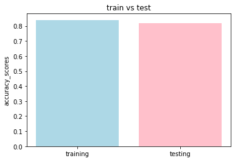

```python
models = ['training','testing']
accuracy_scores = [0.84,0.82]
plt.bar(models, accuracy_scores, color=['lightblue', 'pink'])
plt.ylabel("accuracy_scores")
plt.title("train vs test")
plt.show()
```

- Here,Training accuracy in model is 84%
- Here,Testing accuracy in model is 82%

# LogisticRegression Algorithm Model

```python
# Model Building:
from sklearn.linear_model import LogisticRegression
```

```python
# After scaling the features, the solvers all perform better and sag
lr = LogisticRegression(multi_class = 'auto', solver = 'sag', max_iter = 1000)
```

```python
# Apply the lr object on the dataset(Training Phase)
# Syntax: objectName.fit(Input, Output)
lr.fit(scaled_X_train, y_train)
```

```
LogisticRegression(C=1.0, class_weight=None, dual=False, fit_intercept=True,
                   intercept_scaling=1, l1_ratio=None, max_iter=1000,
                   multi_class='auto', n_jobs=None, penalty='l2',
                   random_state=None, solver='sag', tol=0.0001, verbose=0,
                   warm_start=False)
```

```python
# Predictions on the data
#predict function--> gives the predicted values for training model
# Syntax:objectname.predict(Input)
y_train_pred_lr = lr.predict(scaled_X_train)
y_train_pred_lr
```

```
array([0, 0, 0, ..., 0, 0, 0])
```

```python
# Checks the confusion_matrix for training model
confusion_matrix = metrics.confusion_matrix(y_train, y_train_pred_lr)
confusion_matrix
```

```
array([[993,   0],
       [183,   0]])
```

```python
# Checks the accuracy, classification report for training model
from sklearn.metrics import classification_report
print(classification_report(y_train, y_train_pred_lr))
```

```
              precision    recall  f1-score   support

           0       0.84      1.00      0.92       993
           1       0.00      0.00      0.00       183

    accuracy                           0.84      1176
   macro avg       0.42      0.50      0.46      1176
weighted avg       0.71      0.84      0.77      1176
```

```python
# Checks the accuracy for LogisticRegression Algorithm for train phase
acc_lr = metrics.accuracy_score(y_train, y_train_pred_lr)
acc_lr
```

```
0.8443877551020408
```

```python
# Predictions on the data
#predict function--> gives the predicted values for testing model
# Syntax:objectname.predict(Input)
y_test_pred_lr = lr.predict(scaled_X_test)
y_test_pred_lr
```

```
array([0, 0, 0, 0, 0, 0, 0, 0, 0, 0, 0, 0, 0, 0, 0, 0, 0, 0, 0, 0, 0, 0,
       0, 0, 0, 0, 0, 0, 0, 0, 0, 0, 0, 0, 0, 0, 0, 0, 0, 0, 0, 0, 0, 0,
       0, 0, 0, 0, 0, 0, 0, 0, 0, 0, 0, 0, 0, 0, 0, 0, 0, 0, 0, 0, 0, 0,
       0, 0, 0, 0, 0, 0, 0, 0, 0, 0, 0, 0, 0, 0, 0, 0, 0, 0, 0, 0, 0, 0,
       0, 0, 0, 0, 0, 0, 0, 0, 0, 0, 0, 0, 0, 0, 0, 0, 0, 0, 0, 0, 0, 0,
       0, 0, 0, 0, 0, 0, 0, 0, 0, 0, 0, 0, 0, 0, 0, 0, 0, 0, 0, 0, 0, 0,
       0, 0, 0, 0, 0, 0, 0, 0, 0, 0, 0, 0, 0, 0, 0, 0, 0, 0, 0, 0, 0, 0,
       0, 0, 0, 0, 0, 0, 0, 0, 0, 0, 0, 0, 0, 0, 0, 0, 0, 0, 0, 0, 0, 0,
       0, 0, 0, 0, 0, 0, 0, 0, 0, 0, 0, 0, 0, 0, 0, 0, 0, 0, 0, 0, 0, 0,
       0, 0, 0, 0, 0, 0, 0, 0, 0, 0, 0, 0, 0, 0, 0, 0, 0, 0, 0, 0, 0, 0,
       0, 0, 0, 0, 0, 0, 0, 0, 0, 0, 0, 0, 0, 0, 0, 0, 0, 0, 0, 0, 0, 0,
       0, 0, 0, 0, 0, 0, 0, 0, 0, 0, 0, 0, 0, 0, 0, 0, 0, 0, 0, 0, 0, 0,
       0, 0, 0, 0, 0, 0, 0, 0, 0, 0, 0, 0, 0, 0, 0, 0, 0, 0, 0, 0, 0, 0,
       0, 0, 0, 0, 0, 0, 0, 0])
```

```python
# Checks the confusion_matrix for testing model
confusion_matrix = metrics.confusion_matrix(y_test, y_test_pred_lr)
confusion_matrix
```

```
array([[243,   0],
       [ 51,   0]])
```

```python
# Checks the accuracy, classification report for testing model
from sklearn.metrics import classification_report
print(classification_report(y_test, y_test_pred_lr))
```

```
              precision    recall  f1-score   support

           0       0.83      1.00      0.91       243
           1       0.00      0.00      0.00        51

    accuracy                           0.83       294
   macro avg       0.41      0.50      0.45       294
weighted avg       0.68      0.83      0.75       294
```

```python
# Checks the accuracy for LogisticRegression Algorithm for test phase
acc_lr = metrics.accuracy_score(y_test, y_test_pred_lr)
acc_lr
```

```
0.826530612244898
```

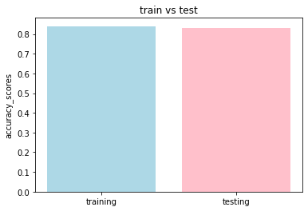

```python
models = ['training','testing']
accuracy_scores = [0.84,0.83]
plt.bar(models, accuracy_scores, color=['lightblue', 'pink'])
plt.ylabel("accuracy_scores")
plt.title("train vs test")
plt.show()
```

- Here,Training accuracy in model is 84%
- Here,Testing accuracy in model is 83%

# Random Forest Classifier Algorithm Model

```python
# Model Building:
from sklearn.ensemble import RandomForestClassifier
rfc = RandomForestClassifier(n_estimators = 100, random_state = 99, criterion = 'entropy', oob_score = True)
```

```python
# Apply the rfc object on the dataset(Training Phase)
# Syntax: objectName.fit(Input, Output)
rfc.fit(scaled_X_train, y_train)
```

```
RandomForestClassifier(bootstrap=True, ccp_alpha=0.0, class_weight=None,
                       criterion='entropy', max_depth=None, max_features='auto',
                       max_leaf_nodes=None, max_samples=None,
                       min_impurity_decrease=0.0, min_impurity_split=None,
                       min_samples_leaf=1, min_samples_split=2,
                       min_weight_fraction_leaf=0.0, n_estimators=100,
                       n_jobs=None, oob_score=True, random_state=99, verbose=0,
                       warm_start=False)
```

```python
# Predictions on the data
#predict function--> gives the predicted values for training model
# Syntax:objectname.predict(Input)
y_train_pred_rfc = rfc.predict(scaled_X_train)
y_train_pred_rfc
```

```
array([0, 0, 0, ..., 0, 0, 0])
```

```python
# Checks the confusion_matrix for training model
confusion_matrix = metrics.confusion_matrix(y_train, y_train_pred_rfc)
confusion_matrix
```

```
array([[993,   0],
       [  0, 183]])
```

```python
# Checks the accuracy, classification report for training model
from sklearn.metrics import classification_report
print(classification_report(y_train, y_train_pred_rfc))
```

```
              precision    recall  f1-score   support

           0       1.00      1.00      1.00       993
           1       1.00      1.00      1.00       183

    accuracy                           1.00      1176
   macro avg       1.00      1.00      1.00      1176
weighted avg       1.00      1.00      1.00      1176
```

```python
# Check the accuracy for Random Forest Classifier Algorithm for train phase
acc_rfc = metrics.accuracy_score(y_train, y_train_pred_rfc)
acc_rfc
```

```
1.0
```

```python
# Predictions on the data
#predict function--> gives the predicted values for testing model
# Syntax:objectname.predict(Input)
y_test_pred_rfc = rfc.predict(scaled_X_test)
y_test_pred_rfc
```

```
array([0, 0, 0, 0, 0, 0, 0, 0, 0, 0, 0, 0, 0, 0, 0, 0, 0, 0, 0, 0, 0, 0,
       0, 0, 0, 0, 0, 0, 0, 0, 0, 0, 0, 0, 0, 0, 0, 1, 0, 0, 0, 0, 0, 0,
       1, 0, 0, 0, 0, 0, 0, 0, 0, 1, 0, 0, 0, 0, 0, 0, 0, 0, 0, 0, 0, 0,
       0, 0, 0, 0, 0, 0, 0, 0, 0, 1, 0, 0, 0, 0, 0, 0, 0, 0, 0, 0, 0, 0,
       0, 0, 0, 0, 0, 0, 0, 0, 0, 0, 0, 0, 1, 0, 0, 0, 0, 0, 0, 0, 0, 0,
       0, 0, 0, 0, 0, 0, 0, 0, 0, 0, 0, 0, 0, 0, 0, 0, 0, 0, 0, 0, 0, 0,
       0, 0, 0, 0, 0, 0, 0, 0, 0, 0, 0, 0, 0, 0, 0, 0, 0, 0, 0, 0, 0, 0,
       0, 0, 0, 0, 0, 0, 0, 0, 0, 0, 0, 0, 0, 0, 0, 0, 0, 0, 0, 0, 0, 0,
       0, 0, 0, 0, 0, 0, 0, 0, 0, 1, 0, 0, 0, 0, 0, 0, 0, 0, 0, 0, 0, 0,
       0, 0, 0, 0, 0, 0, 0, 0, 0, 0, 0, 0, 0, 0, 0, 0, 0, 0, 0, 0, 1, 0,
       0, 0, 0, 0, 1, 0, 0, 0, 0, 0, 0, 0, 0, 1, 0, 0, 0, 0, 0, 0, 0, 1,
       0, 0, 0, 0, 0, 0, 0, 0, 0, 0, 0, 0, 1, 0, 0, 0, 0, 0, 0, 0, 0, 0,
       0, 0, 0, 0, 0, 0, 0, 0, 0, 0, 0, 0, 0, 0, 0, 0, 0, 0, 0, 0, 0, 0,
       0, 0, 0, 0, 0, 0, 0, 0])
```

```python
# Checks the confusion_matrix for testing model
confusion_matrix = metrics.confusion_matrix(y_test, y_test_pred_rfc)
confusion_matrix
```

```
array([[236,   7],
       [ 47,   4]])
```

```python
# Checks the accuracy, classification report for testing model
from sklearn.metrics import classification_report
print(classification_report(y_test, y_test_pred_rfc))
```

```
              precision    recall  f1-score   support

           0       0.83      0.97      0.90       243
           1       0.36      0.08      0.13        51

    accuracy                           0.82       294
   macro avg       0.60      0.52      0.51       294
weighted avg       0.75      0.82      0.76       294
```

```python
# Check the accuracy for Random Forest Classifier Algorithm for test phase
acc_rfc = metrics.accuracy_score(y_test, y_test_pred_rfc)
acc_rfc
```

```
0.8163265306122449
```

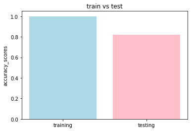

```python
models = ['training','testing']
accuracy_scores = [1.00,0.82]
plt.bar(models, accuracy_scores, color=['lightblue', 'pink'])
plt.ylabel("accuracy_scores")
plt.title("train vs test")
plt.show()
```

- Here,Training accuracy in model is 100%
- Here,Testing accuracy in model is 82%

# GridSearchCV

```python
#Passing list of values  in a dictionary to find the optimum value for each parameter
grid_param = {
    'criterion' : ['entropy','gini'],

    'max_depth' : range(1,11,2),
    'min_samples_leaf' : range(1,6,3)
}
```

```python
#Import the GridSearchCV
from sklearn.model_selection import GridSearchCV


# initialization of GridSearch with the parameters- ModelName and the dictionary of parameters
clf = RandomForestClassifier()
grid_search = GridSearchCV(estimator = clf, param_grid = grid_param)

# applying gridsearch onto dataset
grid_search.fit(X_train, y_train)
```

```
GridSearchCV(cv=None, error_score=nan,
             estimator=RandomForestClassifier(bootstrap=True, ccp_alpha=0.0,
                                              class_weight=None,
                                              criterion='gini', max_depth=None,
                                              max_features='auto',
                                              max_leaf_nodes=None,
                                              max_samples=None,
                                              min_impurity_decrease=0.0,
                                              min_impurity_split=None,
                                              min_samples_leaf=1,
                                              min_samples_split=2,
                                              min_weight_fraction_leaf=0.0,
                                              n_estimators=100, n_jobs=None,
                                              oob_score=False,
                                              random_state=None, verbose=0,
                                              warm_start=False),
             iid='deprecated', n_jobs=None,
             param_grid={'criterion': ['entropy', 'gini'],
                         'max_depth': range(1, 11, 2),
                         'min_samples_leaf': range(1, 6, 3)},
             pre_dispatch='2*n_jobs', refit=True, return_train_score=False,
             scoring=None, verbose=0)
```

```python
# return the optimal parameters
grid_search.best_params_
```

```
{'criterion': 'entropy', 'max_depth': 1, 'min_samples_leaf': 1}
```

```python
#Build the model with best parameters
#Initialized the DT Classifier
clf = RandomForestClassifier(criterion = 'entropy', max_depth = 1, min_samples_leaf = 1)

# We need to fit the model to the data
clf.fit(X_train, y_train)
```

```
RandomForestClassifier(bootstrap=True, ccp_alpha=0.0, class_weight=None,
                       criterion='entropy', max_depth=1, max_features='auto',
                       max_leaf_nodes=None, max_samples=None,
                       min_impurity_decrease=0.0, min_impurity_split=None,
                       min_samples_leaf=1, min_samples_split=2,
                       min_weight_fraction_leaf=0.0, n_estimators=100,
                       n_jobs=None, oob_score=False, random_state=None,
                       verbose=0, warm_start=False)
```

```python
# Prediction on test data
pred_test = clf.predict(X_test)

#Classification Report of actual values and predicted value(GridSearch)
from sklearn.metrics import classification_report
print(classification_report(y_test, pred_test))
```

```
              precision    recall  f1-score   support

           0       0.83      1.00      0.91       243
           1       0.00      0.00      0.00        51

    accuracy                           0.83       294
   macro avg       0.41      0.50      0.45       294
weighted avg       0.68      0.83      0.75       294
```

```python
# Check the accuracy for Random Forest Classifier Algorithm after the gridsearchcv
acc_dt = metrics.accuracy_score(y_test, pred_test)
acc_dt
```

```
0.826530612244898
```

### Best among LogisticRegression , RandomForestClassifier, K-nearest neighbors(KNN)

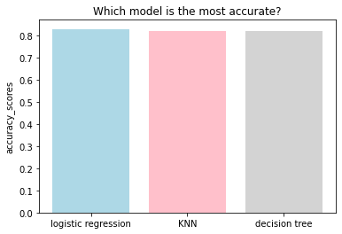

```python
models = ['logistic regression','KNN','decision tree']
accuracy_scores = [0.83, 0.82, 0.82]
plt.bar(models, accuracy_scores, color=['lightblue', 'pink','lightgrey'])
plt.ylabel("accuracy_scores")
plt.title("Which model is the most accurate?")
plt.show()
```